# Bayes Rule with Continuous Random Variables

February 07, 2019

## Obligatory Disclosure

- Ben is an employee of Columbia University, which has received several research grants to develop Stan
- Ben is also a manager of GG Statistics LLC, which uses Stan for business purposes
- According to Columbia University [policy](https://research.columbia.edu/content/conflict-interest-and-research), any such employee who has any equity stake in, a title (such as officer or director) with, or is expected to earn at least \(\$5,000.00\) per year from a private company is required to disclose these facts in presentations
- I do not have any connection to Mapp Biopharmaceutical, which we are going to use as an example today

## Beta Distribution

- The Beta distribution for \(\pi \in \Theta = \left[0,1\right]\) has two positive shape parameters \(a\) and \(b\) and its PDF involves the Beta function \(B\left(a,b\right) = \frac{\Gamma\left(a\right) \Gamma\left(b\right)}{\Gamma\left(a + b\right)}\): \[f\left(\left.\pi\right|a,b\right) = \frac{1}{B\left(a,b\right)} \pi^{a - 1} \left(1 - \pi\right)^{b - 1} \propto \pi^{a - 1} \left(1 - \pi\right)^{b - 1}\]
- Its expectation is \(\mu = \frac{a}{a + b}\) & mode is \(M = \frac{a - 1}{a + b - 2}\) but only exists if \(a,b > 1\)
- Its median, \(m \approx \frac{a - \frac{1}{3}}{a + b - \frac{2}{3}}\), always exists but approximation assumes \(a,b > 1\)
- Given \(M, m \in \left(0,1\right)\), you can [solve](https://www.wolframalpha.com/input/?i=Reduce+function) for \(a > 1\) and \(b > 1\)
  - \(a = \frac{m\left(4M - 3\right) + M}{3\left(M - m\right)}\) while \(b = \frac{m\left(1 - 4M\right) + 5M - 2}{3\left(M - m\right)}\)
  - But \(m\) must be between \(\frac{1}{2}\) and \(M\) in order for \(a > 1\) and \(b > 1\)

## Matching the Prior Predictive Distribution in Stan

```
functions { /* saved as ebola_rng.stan in R's working directory */
  vector ebola_rng(int S, real M, real m, int N, int y) { // must have a _rng suffix
    real common = 3 * (M - m);
    real a = (m * (4 * M - 3) + M) / common;
    real b = (m * (1 - 4 * M) + 5 * M - 2) / common;
    vector[S] post; // size equal to number of simulations
    int s = 1;
    if (a < 1 || b < 1) reject("M and m are inconsistent");
    while (s <= S) {
      real pi_tilde = beta_rng(a, b);          // draw from prior distribution
      int y_tilde = binomial_rng(N, pi_tilde); // draw from prior predictive distribution
      if (y_tilde == y) {                      // keep iff matches observed data
        post[s] = pi_tilde;                    // indexing (mostly) works like in R
        s += 1;                                // s += 1; is equivalent to s = s + 1;
      }
    }
    return sort_asc(post);                     // easier to plot CDF if sorted ascending
  }
}
```

## Updating Beliefs about the Success Probability

```r
rstan::expose_stan_functions("ebola_rng.stan") # puts Stan functions into R's workspace
M <- 2 / 3; m <- 0.635; a <- (m * (4 * M - 3) + M) / (3 * (M - m))
b <- (m * (1 - 4 * M) + 5 * M - 2) / (3 * (M - m))
N <- 7L; y <- 5L; S <- 10000L; post <- ebola_rng(S, M, m, N, y) # call as an R function
```

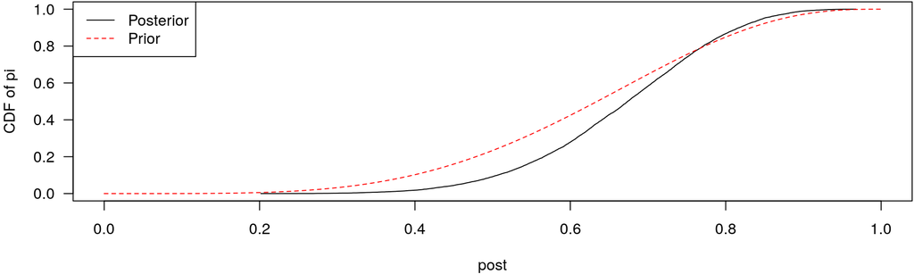

```r
plot(post, y = (1:S) / S, type = "l", xlim = 0:1, ylab = "CDF of pi")
curve(pbeta(pi, a, b), from = 0, to = 1, add = TRUE, col = 2, lty = 2, xname = "pi")
legend("topleft", legend = c("Posterior", "Prior"), col = 1:2, lty = 1:2)
```

## Numerator of Bayes Rule

```
functions { /* saved as numerator.stan in R's working directory */
  vector numerator(vector pi, real M, real m, int N, int y) {
    real common = 3 * (M - m);
    real a = (m * (4 * M - 3) + M) / common;
    real b = (m * (1 - 4 * M) + 5 * M - 2) / common;
    int K = rows(pi); vector[K] log_pi = log(pi);
    vector[K] log1m_pi = log1m(pi); // log1m(x) == log(1 - x) but numerically accurate
    vector[K] log_prior = (a - 1) * log_pi + (b - 1) * log1m_pi - lbeta(a, b);   // l prefix
    vector[K] log_likelihood =  y * log_pi + (N - y) * log1m_pi + lchoose(N, y); // means log
    return exp(log_prior + log_likelihood); // equals exp(log_prior) * exp(log_likelihood)
  }
}
```

```r
rstan::expose_stan_functions("numerator.stan")
```

```r
(denom <- integrate(numerator, lower = 0, upper = 1, M = M, m = m, N = N, y = y)$value)
```

```
## [1] 0.2179323
```

## Same Info from the Probability Density Functions

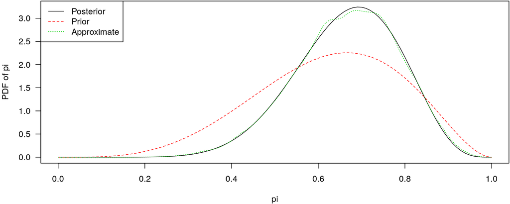

```r
curve(numerator(pi, M, m, N, y) / denom, from = 0, to = 1, xname = "pi", ylab = "PDF of pi")
curve(dbeta(pi, a, b), from = 0, to = 1, col = 2, lty = 2, xname = "pi", add = TRUE)
lines(density(post, from = 0, to = 1),   col = 3, lty = 3)
legend("topleft", legend = c("Posterior", "Prior", "Approximate"), col = 1:3, lty = 1:3)
```

## Deriving the Posterior Distribution Analytically

- Survivals are Binomial with probability \(\pi\). Thus, BEFORE you see the results \(f\left(\left.y\right|N,\pi\right)={N \choose y}\pi^{y}\left(1-\pi\right)^{N-y}\) while the Beta PDF is again \(f\left(\left.\pi\right|a,b\right) = \frac{1}{B\left(a,b\right)} \pi^{a - 1} \left(1 - \pi\right)^{b - 1}\), so \(B\left(a,b\right) = \int_0^1 \pi^{a - 1} \left(1 - \pi\right)^{b - 1} d\pi\)
- AFTER \(y = 5\) out of \(N = 7\) people were cured, what are your beliefs about \(\pi\)? \[f\left(\left.\pi\right|a,b,N,y\right) = \frac{f\left(\left.\pi\right|a,b\right) L\left(\pi;N,y\right)} {\int_0^1 f\left(\left.\pi\right|a,b\right) L\left(\pi;N,y\right) d\pi} \propto \\ \pi^{a - 1} \left(1 - \pi\right)^{b - 1} \pi^{y}\left(1-\pi\right)^{N-y} = \pi^{a + y - 1} \left(1 - \pi\right)^{b + N - y - 1} = \pi^{a^\ast - 1} \left(1 - \pi\right)^{b^\ast - 1}\] where \(a^{\ast}=a+y\) and \(b^{\ast}=b+N-y\)
- \(f\left(\left.\pi\right|a^\ast,b^\ast\right)\) has the kernel of a Beta PDF and therefore the normalizing constant must be the reciprocal of \(B\left(a^\ast,b^\ast\right)\)

## Checking the Posterior CDF

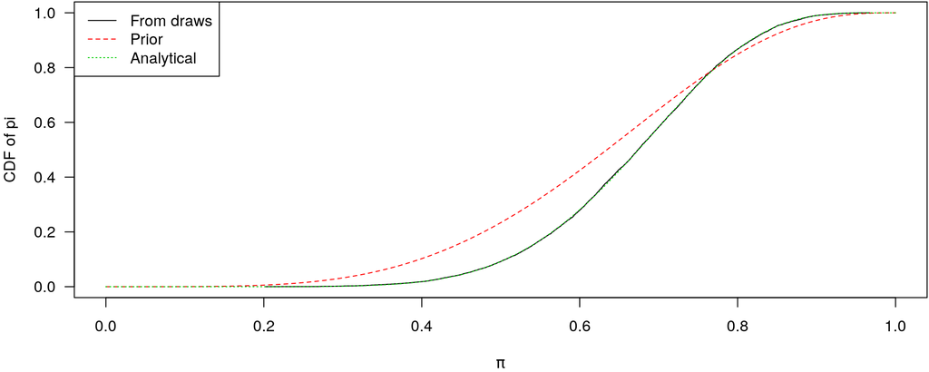

```r
plot(post, y = (1:S) / S, type = "l", xlim = 0:1, xlab = expression(pi), ylab = "CDF of pi")
curve(pbeta(pi, a, b), from = 0, to = 1, add = TRUE, col = 2, lty = 2, xname = "pi")
curve(pbeta(pi, a + y, b + N - y), from = 0, to = 1, add = TRUE, col = 3, lty = 3, xname = "pi")
legend("topleft", legend = c("From draws", "Prior", "Analytical"), col = 1:3, lty = 1:3)
```

## Checking the Posterior PDF

```r
c(exact = (a + y) / (a + y + b + N - y), approximate = mean(post)) # posterior expectation
```

```
##       exact approximate
##   0.6666667   0.6665921
```

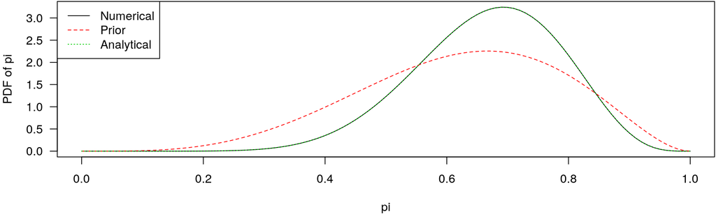

```r
curve(numerator(pi, M, m, N, y) / denom, from = 0, to = 1, xname = "pi", ylab = "PDF of pi")
curve(dbeta(pi, a, b), from = 0, to = 1, col = 2, lty = 2, xname = "pi", add = TRUE)
curve(dbeta(pi, a + y, b + N - y), from = 0, to = 1, col = 3, lty = 3, xname = "pi", add = TRUE)
legend("topleft", legend = c("Numerical", "Prior", "Analytical"), col = 1:3, lty = 1:3)
```

## Properties of this Posterior Distribution

- The first approach illustrates a key point: The posterior PDF is the function closest to the prior PDF that satisfies a constraint given by the observed data
- Posterior expectation is between the prior expectation and sample mean

```r
c(prior = a / (a + b), posterior = (a + y) / (a + y + b + N - y), sample = y / N)
```

```
##     prior posterior    sample
## 0.6232877 0.6666667 0.7142857
```

- As \(N \uparrow \infty\) with \(a\) and \(b\) fixed, the posterior mean approaches \(\frac{y}{N}\)
- It does not matter if the data arrives one observation at a time, all at once, or somewhere in between. After \(N\) tries and \(y\) successes your posterior distribution will be the same, namely Beta with parameters \(a^\ast = a + y\) and \(b^\ast = b + N - y\), and contains all the information available from past data
- Ergo, you can use your posterior PDF as your prior PDF for the next dataset